# Automated SDR (client onboarding)

# Gmail, Google Drive, Clickup, Airtable, Slack

99fold | matt@99foldai.com | @99foldai

# Summary

Detailed and systemised automated workflow for Sales Development Representatives (SDR) and leads/client onboarding and nurturing, starting from client onboarding, auto processing and filtering new client data, creating shared team/client databases, and initiating new intra- and inter- personal comms for relevant team members and client.

# Who is this perfect for?

## Marketing agency

## Creative agency

## Digital design business

## Service provider

## Brand strategist

## Logo designer

## Web designer

## Sales teams

## Recruitment agency

## Tourism agency

# How does it work?

1. Watch for new client email  
   Monitor inbox for incoming emails from new or existing clients.
2. Download client data  
   Retrieve attached documents or files from the client’s email.
3. Filter relevant data  
   Apply conditions to isolate only the necessary or actionable data.
4. Upload filtered data to database  
   Send cleaned and structured data to the appropriate database.
5. Download relevant data  
   Pull additional or related information needed for the process from a data source.
6. Create shared database and new record  
   Initialize a shared workspace and log a new entry with client data.
7. Update team with parsed info  
   Notify internal team members with the extracted and organized client information.
8. Create shared database (Airtable, Clickup)  
   Generate an Airtable/Clickup workspace for collaborative client or project data.
9. Update team/client (Slack)  
   Send automated status or data updates to team or client via Slack.
10. Send email to team/client  
    Email final results, updates, or next steps to team and client email channels

# Pathway

Low-friction integration with your existing apps, workflow, and systems

[figure not shown]

[figure not shown]

[figure not shown]

[figure not shown]

[figure not shown]

[figure not shown]

# Process

[figure not shown]

> Step-by-step integration with existing client database apps

> Seamlessly create a new team/client shared database that auto populates

[figure not shown]

[figure not shown]

# More benefits

### Tasks

- Automate the process of client management and nurturing
- Enhance team collaboration through shared databases
- Streamline communication with clients and team members

### Benefits

- Efficient data management leads to quicker client onboarding and project delivery, ultimately boosting sales
- Timely updates and accurate data handling enhance client satisfaction and trust
- Streamlined workflows reduce manual errors and save time, allowing teams to focus on strategic initiatives

# Example

Example of automated workflow (replace with your own tasks/apps)

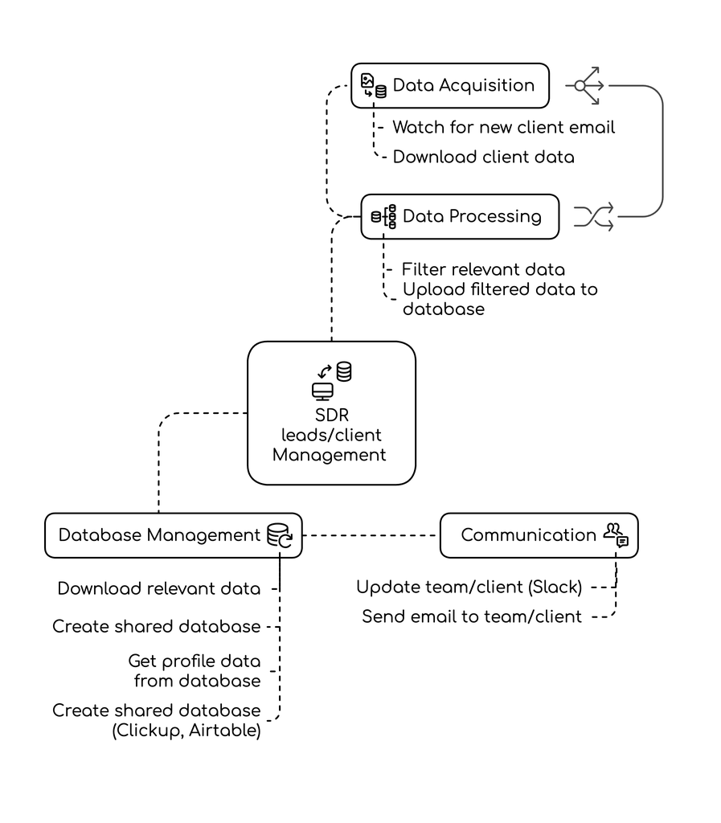

[figure not shown]